# Transfer Learning avec ResNet50

Dans ce notebook, on résout le **même problème** que dans le notebook du CNN entraîné de zéro : classer des radios des poumons en trois catégories (`NORMAL`, `PNEUMONIA_bacteria`, `PNEUMONIA_viral`). Ce qui change, c'est la méthode.

Ici on fait du **transfert learning** : au lieu de partir de zéro, on réutilise **ResNet50**, un gros réseau déjà entraîné sur ImageNet (des millions d'images variées). Il a donc déjà appris à reconnaître des formes, des textures et des contours généraux. On garde cette « base » et on ne réentraîne qu'une petite partie + une nouvelle tête adaptée à nos 3 classes.

L'intérêt par rapport au CNN from scratch : on a besoin de moins de données et de moins de temps pour obtenir de bons résultats. Les deux notebooks suivent les mêmes grandes étapes pour que la comparaison soit honnête.

## 1. Imports, configuration et préparation des données

Cette première cellule fait beaucoup de choses d'un coup :

- les **imports** (TensorFlow/Keras, pandas, NumPy, matplotlib/seaborn, scikit-learn, et surtout ResNet50 avec son `preprocess_input`) ;
- la **configuration** (taille d'image 224×224, batch de 32, les 3 classes cibles) ;
- la fonction `build_split_dataframe` qui parcourt les dossiers, lit le nom des fichiers pour deviner si une pneumonie est virale ou bactérienne, et range tout dans un tableau pandas ;
- `load_image` et `make_dataset` qui transforment ces chemins en `tf.data.Dataset` prêts pour le modèle ;
- enfin le **découpage** train/val/test (80/20 sur train+val, en gardant les proportions de classes avec `stratify`).

```python
import os
from pathlib import Path
import tensorflow as tf
import pandas as pd
import numpy as np
import matplotlib.pyplot as plt
import seaborn as sns
from sklearn.metrics import classification_report, confusion_matrix
from sklearn.model_selection import train_test_split
from tensorflow.keras import layers, models
from tensorflow.keras.applications import ResNet50
from tensorflow.keras.applications.resnet50 import preprocess_input
from tensorflow.keras.callbacks import EarlyStopping, ModelCheckpoint, ReduceLROnPlateau

DATASET_ROOT = Path("../data/chest_Xray")
SPLITS = ["train", "val", "test"]
SOURCE_LABELS = ["NORMAL", "PNEUMONIA"]
TARGET_LABELS = ["NORMAL", "PNEUMONIA_bacteria", "PNEUMONIA_viral"]
LABEL_TO_INDEX = {name: idx for idx, name in enumerate(TARGET_LABELS)}
NUM_CLASSES = len(TARGET_LABELS)
IMG_SIZE = 224
BATCH_SIZE = 32
AUTOTUNE = tf.data.AUTOTUNE


def build_split_dataframe():
    rows = []
    for split in SPLITS:
        for source_label in SOURCE_LABELS:
            class_path = os.path.join(DATASET_ROOT, split, source_label)
            for filename in sorted(os.listdir(class_path)):
                if not filename.lower().endswith((".png", ".jpg", ".jpeg")):
                    continue

                if source_label == "NORMAL":
                    label = "NORMAL"
                    pneumonia_type = "Aucune"
                else:
                    lowered = filename.lower()
                    if "virus" in lowered:
                        label = "PNEUMONIA_viral"
                        pneumonia_type = "virus"
                    elif "bacteria" in lowered:
                        label = "PNEUMONIA_bacteria"
                        pneumonia_type = "bacteria"
                    else:
                        continue

                rows.append({
                    "split": split,
                    "label": label,
                    "pneumonia_type": pneumonia_type,
                    "filename": filename,
                    "path": os.path.join(class_path, filename),
                })

    frame = pd.DataFrame(rows)
    frame["class_index"] = frame["label"].map(LABEL_TO_INDEX)
    return frame


def load_image(path, label_index):
    image = tf.io.read_file(path)
    image = tf.image.decode_image(image, channels=3, expand_animations=False)
    image = tf.image.resize(image, (IMG_SIZE, IMG_SIZE))
    image = tf.cast(image, tf.float32)
    label = tf.one_hot(label_index, depth=NUM_CLASSES)
    return image, label


def make_dataset(frame, shuffle=False):
    paths = frame["path"].to_numpy()
    labels = frame["class_index"].to_numpy()
    dataset = tf.data.Dataset.from_tensor_slices((paths, labels))
    if shuffle:
        dataset = dataset.shuffle(buffer_size=len(frame), reshuffle_each_iteration=True)
    dataset = dataset.map(load_image, num_parallel_calls=AUTOTUNE)
    dataset = dataset.batch(BATCH_SIZE).prefetch(AUTOTUNE)
    return dataset


df = build_split_dataframe()
train_val_df = df[df["split"].isin(["train", "val"])].copy()
test_df = df[df["split"] == "test"].copy()
train_df, val_df = train_test_split(
    train_val_df,
    test_size=0.20,
    random_state=42,
    stratify=train_val_df["label"],
)
```

## 2. Exploration des données

On regarde comment les images sont réparties par split et par classe (tableaux + diagramme en barres), et on affiche un exemple d'image de chaque classe. Comme dans l'autre notebook, ça permet de repérer le **déséquilibre** entre classes et de vérifier visuellement à quoi ressemblent les radios.

```
   split   label pneumonia_type           filename
0  train  NORMAL         Aucune  IM-0115-0001.jpeg
1  train  NORMAL         Aucune  IM-0117-0001.jpeg
2  train  NORMAL         Aucune  IM-0119-0001.jpeg
3  train  NORMAL         Aucune  IM-0122-0001.jpeg
4  train  NORMAL         Aucune  IM-0125-0001.jpeg

   split               label  count
0   test              NORMAL    234
1   test  PNEUMONIA_bacteria    242
2   test     PNEUMONIA_viral    148
3  train              NORMAL   1341
4  train  PNEUMONIA_bacteria   2530
5  train     PNEUMONIA_viral   1345
6    val              NORMAL      8
7    val  PNEUMONIA_bacteria      8

split
test      242
train    2530
val         8
dtype: int64
split
test      148
train    1345
dtype: int64
```

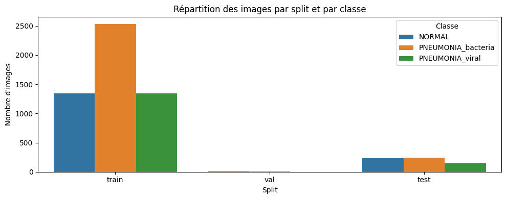

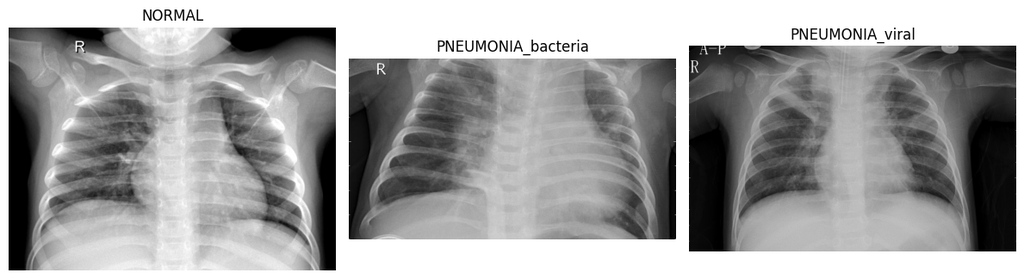

```python
# Exploration des données en amont sur 3 classes

print(df[["split", "label", "pneumonia_type", "filename"]].head())
print()
print(df.groupby(["split", "label"]).size().reset_index(name="count"))
print()
print(df[df["label"] == "PNEUMONIA_bacteria"].groupby("split").size())
print(df[df["label"] == "PNEUMONIA_viral"].groupby("split").size())

plt.figure(figsize=(10, 4))
sns.countplot(data=df, x="split", hue="label", order=SPLITS, hue_order=TARGET_LABELS)
plt.title("Répartition des images par split et par classe")
plt.xlabel("Split")
plt.ylabel("Nombre d'images")
plt.legend(title="Classe")
plt.tight_layout()
plt.show()

fig, axes = plt.subplots(1, 3, figsize=(12, 4))
for axis, label in zip(axes, TARGET_LABELS):
    sample = df[df["label"] == label].sample(1, random_state=42).iloc[0]
    image = tf.keras.utils.load_img(sample["path"], color_mode="grayscale")
    axis.imshow(image, cmap="gray")
    axis.set_title(label)
    axis.axis("off")

plt.tight_layout()
plt.show()
```

# Explication des imports supplémentaires

- `preprocess_input` : applique le prétraitement spécifique à ResNet50 (normalisation comme sur ImageNet), ce qui aligne les radios sur ce que le backbone a vu pendant son pré-entraînement et améliore la qualité des features extraites.
- `EarlyStopping`, `ModelCheckpoint`, `ReduceLROnPlateau` : callbacks utilisés pour contrôler l'entraînement, éviter le sur-apprentissage et adapter le learning rate. En pratique, ils aident à obtenir une meilleure généralisation sur les trois classes du problème : `NORMAL`, `PNEUMONIA_bacteria` et `PNEUMONIA_viral`.

## 3. Rappel de la configuration

On refixe la taille des images et des batchs (déjà définies plus haut, c'est juste un rappel explicite avant de construire les datasets).

```python
IMG_SIZE = 224
BATCH_SIZE = 32
```

## 4. Construction des datasets train / val / test

On crée les trois jeux de données avec `make_dataset` et on affiche le nombre d'images par classe dans chacun. Seul le train est mélangé (`shuffle=True`). On retrouve ici le même déséquilibre de classes que dans l'autre notebook.

```python
train_ds = make_dataset(train_df, shuffle=True)
train_class_names = TARGET_LABELS
print("Classes d'entraînement:", train_class_names)
print(train_df["label"].value_counts().reindex(TARGET_LABELS, fill_value=0))
```

```
Classes d'entraînement: ['NORMAL', 'PNEUMONIA_bacteria', 'PNEUMONIA_viral']
label
NORMAL                1079
PNEUMONIA_bacteria    2030
PNEUMONIA_viral       1076
Name: count, dtype: int64
```

```python
val_ds = make_dataset(val_df)
print(val_df["label"].value_counts().reindex(TARGET_LABELS, fill_value=0))
```

```
label
NORMAL                270
PNEUMONIA_bacteria    508
PNEUMONIA_viral       269
Name: count, dtype: int64
```

```python
test_ds = make_dataset(test_df)
print(test_df["label"].value_counts().reindex(TARGET_LABELS, fill_value=0))
```

```
label
NORMAL                234
PNEUMONIA_bacteria    242
PNEUMONIA_viral       148
Name: count, dtype: int64
```

## 5. Data augmentation

Comme pour le CNN from scratch, on applique de la **data augmentation** sur le train : retournement horizontal, petite rotation, zoom et variation de contraste. Les commentaires du code expliquent pourquoi chaque transformation reste « raisonnable » sur des radios médicales (par exemple pas de retournement vertical : une radio à l'envers n'a pas de sens). Le but n'est pas d'ajouter des images, mais de montrer plus de variété au modèle à chaque epoch pour qu'il généralise mieux.

```python
# Augmentation des données avec des transformations aléatoires pour améliorer la généralisation du modèle
# Ces transformations sont choisies pour refléter des variations réalistes dans les images médicales
# et éviter de créer des images non représentatives ou médicalement incorrectes.
# ATTENTION : La data augmentation n’est pas de l’oversampling conceptuel, c’est une augmentation de support du manifold. (=/= une duplication des données avec SMOTE, Oversampling, etc.)

data_augmentation = tf.keras.Sequential([
    tf.keras.layers.RandomFlip("horizontal"),   # Les radios peuvent être prises côté gauche ou droit. Anatomiquement valide (le cœur change juste de côté visuellement). Pas de flip vertical : une radio à l'envers n'a aucun sens médical.
    tf.keras.layers.RandomRotation(0.05),       # Petite rotation pour simuler des variations dans la prise de vue Patient peut être légèrement penché lors de la prise. Pas plus de ±5-7° : au-delà, ça déforme l'anatomie de manière non réaliste.
    tf.keras.layers.RandomZoom(0.1),            # Zoom léger pour simuler des variations de distance entre le patient et la machine à rayons X. Pas plus de ±10% : au-delà, ça peut couper des parties importantes de l'image.
    tf.keras.layers.RandomContrast(0.2),        # Variation de contraste pour simuler des différences dans les réglages de la machine à rayons X ou les conditions d'éclairage. Pas plus de ±20% : au-delà, ça peut rendre l'image irréaliste.
    ])                                          # !! Les pneumonies se manifestent par des variations de contraste dans les poumons. Une augmentation excessive pourrait masquer ces signes. !!!


"""
Comment ça marche concrètement:

À chaque epoch, les transformations changent :

Epoch 1 : Image 1 → flip + rotation -3°
Epoch 2 : Image 1 → pas de flip + rotation +1°
Epoch 3 : Image 1 → flip + zoom 7%
Etc.

Pourquoi ça marche alors ?
Sur 20 epochs :

Sans augmentation : Le modèle voit 624 images identiques 20 fois
Avec augmentation : Le modèle voit ~12,480 variations des 624 images (chaque epoch = nouvelles transformations)
Donc on augmente pas le nombre d'images, mais la diversité des images vues par le modèle.
"""
```

```
"\nComment ça marche concrètement:\n\nÀ chaque epoch, les transformations changent :\n\nEpoch 1 : Image 1 → flip + rotation -3°\nEpoch 2 : Image 1 → pas de flip + rotation +1°\nEpoch 3 : Image 1 → flip + zoom 7%\nEtc.\n\nPourquoi ça marche alors ?\nSur 20 epochs :\n\nSans augmentation : Le modèle vo…
```

## 6. Prétraitement ResNet50 + pipeline tf.data

Étape importante et **spécifique au transfert learning** : on applique `preprocess_input`, le prétraitement exact que ResNet50 attend (la même normalisation qu'au moment de son pré-entraînement sur ImageNet). Sans ça, les images ne seraient pas dans le bon format pour le réseau et les résultats seraient moins bons.

On enchaîne data augmentation → preprocessing sur le train (sans cache, pour garder une augmentation différente à chaque epoch), et juste preprocessing + cache sur val/test. Le `prefetch` accélère l'alimentation du modèle.

```python
# On applique l'augmentation de données uniquement sur le jeu d'entraînement,
train_ds_augmented = train_ds.map(lambda x, y: (data_augmentation(x, training=True), y))

# Puis on applique le prétraitement adapté à ResNet50 (normalisation spécifique ImageNet)
AUTOTUNE = tf.data.AUTOTUNE

# IMPORTANT : on ne met pas de cache sur le train après data_augmentation
train_ds_prep = train_ds_augmented.map(lambda x, y: (preprocess_input(x), y)).shuffle(1000).prefetch(AUTOTUNE)
val_ds_prep = val_ds.map(lambda x, y: (preprocess_input(x), y)).cache().prefetch(AUTOTUNE)
test_ds_prep = test_ds.map(lambda x, y: (preprocess_input(x), y)).cache().prefetch(AUTOTUNE)
```

# Explication de la pipeline TF.data + prétraitement

- `train_ds_augmented` : contient les images d'entraînement avec data augmentation (flip, rotation, zoom, contraste), ce qui augmente la diversité des exemples vus à chaque epoch et réduit le risque d'overfitting.
- `train_ds_prep` : applique ensuite `preprocess_input`, mélange les données avec `shuffle(1000)` et utilise `prefetch(AUTOTUNE)` pour alimenter le GPU sans attendre l'I/O. On **ne met pas de cache** ici pour garder une augmentation aléatoire à chaque epoch.
- `val_ds_prep` et `test_ds_prep` : on applique `preprocess_input` puis `cache().prefetch(AUTOTUNE)` (pas de data augmentation sur val/test). Cela stabilise et accélère l'évaluation sans changer les données. Toutes ces étapes visent à améliorer la qualité et la diversité des données vues par le modèle, ce qui permet de réduire faux positifs et faux négatifs dans la matrice de confusion.

## 7. Chargement du backbone ResNet50 pré-entraîné

On charge **ResNet50** avec ses poids appris sur ImageNet, mais sans sa dernière couche (`include_top=False`), car celle-ci servait à classer les 1000 catégories d'ImageNet, pas nos 3 classes.

Juste après, on **gèle** ce backbone (`base_model.trainable = False`) : ses poids ne bougeront pas pendant la première phase. On garde ainsi tout ce que ResNet50 a déjà appris, et on n'entraîne au début que la partie qu'on ajoute par-dessus.

```python
# Charger un modèle préentraîné (ResNet50) sans la couche finale
base_model = ResNet50(weights='imagenet', include_top=False, input_shape=(224, 224, 3))
```

```python
# Geler les couches de base pour ne pas les entraîner
base_model.trainable = False
```

## 8. Tête de classification

On branche par-dessus ResNet50 nos propres couches : un `GlobalAveragePooling2D` qui résume les features de ResNet50 en un vecteur, une couche `Dense(512)` + `ReLU`, un `Dropout(0.4)` contre le surapprentissage, et enfin une couche `Dense(3)` + `softmax` pour sortir les probabilités des 3 classes. C'est cette tête, légère, qu'on entraîne en premier.

```python
# Ajouter des couches personnalisées pour ta tâche de classification multi-classes
model = models.Sequential([
    base_model,
    layers.GlobalAveragePooling2D(),
    layers.Dense(512, activation='relu'),
    layers.Dropout(0.4),
    layers.Dense(3, activation='softmax')  # 3 classes : Normal, Pneumonia_bacteria, Pneumonia_viral
])
```

# Explication de la tête du modèle

- `GlobalAveragePooling2D` : compresse les cartes de features spatiales de ResNet50 en un vecteur global, ce qui réduit le nombre de paramètres et le risque d'overfitting.
- `Dense(512, activation='relu')` : couche entièrement connectée plus compacte (512 neurones au lieu de 1024), suffisante pour séparer trois classes tout en limitant la complexité.
- `Dropout(0.4)` : désactive aléatoirement 40 % des neurones pendant l'entraînement, ce qui force le modèle à ne pas trop dépendre de quelques features spécifiques et améliore la généralisation. Ensemble, ces choix aident le modèle à mieux généraliser sur des radios jamais vues, et donc à se rapprocher d'une matrice de confusion idéale.

## 9. Compilation

On configure l'entraînement avec l'optimiseur `Adam`, la perte `categorical_crossentropy` (adaptée ici car les labels sont en one-hot) et plusieurs métriques : accuracy, AUC et AUC-PR. On suit l'AUC car c'est une mesure robuste quand les classes sont déséquilibrées.

```python
# Compiler le modèle
model.compile(
    optimizer='adam',
    loss='categorical_crossentropy',
    metrics=[
        tf.keras.metrics.CategoricalAccuracy(name="accuracy"),
        tf.keras.metrics.AUC(name="auc", multi_label=True, num_labels=3),
        tf.keras.metrics.AUC(curve="PR", name="auc_pr", multi_label=True, num_labels=3)
    ]
)
```

## 10. Validation croisée (5-fold)

Comme dans l'autre notebook, on fait une validation croisée en 5 folds pour vérifier la stabilité du modèle. À chaque fold, on recrée un modèle propre (`clone_model`), on l'entraîne sur 4/5 des données et on le valide sur le 1/5 restant, avec ses propres callbacks. Ça permet de voir si les performances sont régulières d'un découpage à l'autre.

```python
# Cross-validation stratifiée sur le train fusionné (90%)
# La CV est une boucle extérieure : pour chaque fold, on recrée et réentraîne un modèle complet.
from sklearn.model_selection import StratifiedKFold

skf = StratifiedKFold(n_splits=5, shuffle=True, random_state=42)
X = train_df["path"].to_numpy()
y = train_df["class_index"].to_numpy()

cv_scores = []

for fold, (fold_train_idx, fold_val_idx) in enumerate(skf.split(X, y), start=1):
    print(f"\n===== Fold {fold}/5 =====")

    fold_train_df = train_df.iloc[fold_train_idx].copy()
    fold_val_df = train_df.iloc[fold_val_idx].copy()

    fold_train_ds = make_dataset(fold_train_df, shuffle=True)
    fold_val_ds = make_dataset(fold_val_df)

    fold_train_ds_augmented = fold_train_ds.map(lambda x, y: (data_augmentation(x, training=True), y))
    fold_train_ds_prep = fold_train_ds_augmented.map(lambda x, y: (preprocess_input(x), y)).shuffle(1000).prefetch(AUTOTUNE)
    fold_val_ds_prep = fold_val_ds.map(lambda x, y: (preprocess_input(x), y)).cache().prefetch(AUTOTUNE)

    fold_model = tf.keras.models.clone_model(model)
    fold_model.compile(
        optimizer='adam',
        loss='categorical_crossentropy',
        metrics=[
            tf.keras.metrics.CategoricalAccuracy(name="accuracy"),
            tf.keras.metrics.AUC(name="auc", multi_label=True, num_labels=3),
            tf.keras.metrics.AUC(curve="PR", name="auc_pr", multi_label=True, num_labels=3),
        ],
    )

    fold_callbacks = [
        EarlyStopping(
            monitor='val_auc',
            mode='max',
            patience=2,
            restore_best_weights=True,
            verbose=1,
        ),
        ReduceLROnPlateau(
            monitor='val_loss',
            factor=0.2,
            patience=1,
            min_lr=1e-6,
            verbose=1,
        ),
    ]

    fold_model.fit(
        fold_train_ds_prep,
        epochs=5,
        validation_data=fold_val_ds_prep,
        callbacks=fold_callbacks,
        verbose=1,
    )

    fold_scores = fold_model.evaluate(fold_val_ds_prep, verbose=0)
    cv_scores.append(fold_scores)
    print(f"Fold {fold} scores: {fold_scores}")

print("CV scores:", cv_scores)
```

```
===== Fold 1/5 =====
105/105 ━━━━━━━━━━━━━━━━━━━━ 92s 729ms/step - accuracy: 0.4158 - auc: 0.5002 - auc_pr: 0.3341 - loss: 2.3818 - val_accuracy: 0.4851 - val_auc: 0.4447 - val_auc_pr: 0.3052 - val_loss: 1.0572 - learning_rate: 0.0010
105/105 ━━━━━━━━━━━━━━━━━━━━ 0s 524ms/step - accuracy: 0.4658 - auc: 0.4845 - auc_pr: 0.3305 - loss: 1.0934
Epoch 2: ReduceLROnPlateau reducing learning rate to 0.00020000000949949026.
105/105 ━━━━━━━━━━━━━━━━━━━━ 84s 662ms/step - accuracy: 0.4848 - auc: 0.4952 - auc_pr: 0.3332 - loss: 1.0801 - val_accuracy: 0.4851 - val_auc: 0.5448 - val_auc_pr: 0.3577 - val_loss: 1.0633 - learning_rate: 0.0010
105/105 ━━━━━━━━━━━━━━━━━━━━ 89s 713ms/step - accuracy: 0.4851 - auc: 0.5010 - auc_pr: 0.3327 - loss: 1.0660 - val_accuracy: 0.4851 - val_auc: 0.5440 - val_auc_pr: 0.3624 - val_loss: 1.0549 - learning_rate: 2.0000e-04
105/105 ━━━━━━━━━━━━━━━━━━━━ 92s 704ms/step - accuracy: 0.4851 - auc: 0.5239 - auc_pr: 0.3463 - loss: 1.0548 - val_accuracy: 0.4851 - val_auc: 0.6050 - val_auc_pr: 0.4235 - val_loss: 1.0527 - learning_rate: 2.0000e-04
105/105 ━━━━━━━━━━━━━━━━━━━━ 83s 668ms/step - accuracy: 0.4851 - auc: 0.5260 - auc_pr: 0.3522 - loss: 1.0550 - val_accuracy: 0.4851 - val_auc: 0.6709 - val_auc_pr: 0.5292 - val_loss: 1.0504 - learning_rate: 2.0000e-04
Restoring model weights from the end of the best epoch: 5.
Fold 1 scores: [1.0504390001296997, 0.4850656986236572, 0.670893669128418, 0.5291561484336853]

===== Fold 2/5 =====
105/105 ━━━━━━━━━━━━━━━━━━━━ 88s 684ms/step - accuracy: 0.4047 - auc: 0.4776 - auc_pr: 0.3145 - loss: 2.2766 - val_accuracy: 0.4851 - val_auc: 0.4702 - val_auc_pr: 0.3170 - val_loss: 1.0525 - learning_rate: 0.0010
105/105 ━━━━━━━━━━━━━━━━━━━━ 0s 541ms/step - accuracy: 0.4946 - auc: 0.5074 - auc_pr: 0.3406 - loss: 1.0540
Epoch 2: ReduceLROnPlateau reducing learning rate to 0.00020000000949949026.
105/105 ━━━━━━━━━━━━━━━━━━━━ 84s 677ms/step - accuracy: 0.4812 - auc: 0.5086 - auc_pr: 0.3392 - loss: 1.0629 - val_accuracy: 0.4851 - val_auc: 0.4913 - val_auc_pr: 0.3405 - val_loss: 1.0595 - learning_rate: 0.0010
105/105 ━━━━━━━━━━━━━━━━━━━━ 0s 563ms/step - accuracy: 0.4906 - auc: 0.4740 - auc_pr: 0.3236 - loss: 1.0636
Epoch 3: ReduceLROnPlateau reducing learning rate to 4.0000001899898055e-05.
105/105 ━━━━━━━━━━━━━━━━━━━━ 87s 707ms/step - accuracy: 0.4851 - auc: 0.4780 - auc_pr: 0.3229 - loss: 1.0664 - val_accuracy: 0.4851 - val_auc: 0.4782 - val_auc_pr: 0.3304 - val_loss: 1.0552 - learning_rate: 2.0000e-04
105/105 ━━━━━━━━━━━━━━━━━━━━ 0s 817ms/step - accuracy: 0.4626 - auc: 0.5001 - auc_pr: 0.3408 - loss: 1.0688
Epoch 4: ReduceLROnPlateau reducing learning rate to 8.000000525498762e-06.
105/105 ━━━━━━━━━━━━━━━━━━━━ 124s 1s/step - accuracy: 0.4851 - auc: 0.4892 - auc_pr: 0.3302 - loss: 1.0623 - val_accuracy: 0.4851 - val_auc: 0.4923 - val_auc_pr: 0.3368 - val_loss: 1.0556 - learning_rate: 4.0000e-05
105/105 ━━━━━━━━━━━━━━━━━━━━ 0s 653ms/step - accuracy: 0.4836 - auc: 0.4705 - auc_pr: 0.3183 - loss: 1.0656
Epoch 5: ReduceLROnPlateau reducing learning rate to 1.6000001778593287e-06.
105/105 ━━━━━━━━━━━━━━━━━━━━ 100s 787ms/step - accuracy: 0.4851 - auc: 0.4870 - auc_pr: 0.3282 - loss: 1.0621 - val_accuracy: 0.4851 - val_auc: 0.4924 - val_auc_pr: 0.3370 - val_loss: 1.0557 - learning_rate: 8.0000e-06
Restoring model weights from the end of the best epoch: 5.
Fold 2 scores: [1.0557364225387573, 0.4850656986236572, 0.4924274682998657, 0.3369976580142975]

===== Fold 3/5 =====
105/105 ━━━━━━━━━━━━━━━━━━━━ 89s 686ms/step - accuracy: 0.4182 - auc: 0.4875 - auc_pr: 0.3249 - loss: 2.1499 - val_accuracy: 0.4851 - val_auc: 0.4536 - val_auc_pr: 0.3041 - val_loss: 1.0658 - learning_rate: 0.0010
105/105 ━━━━━━━━━━━━━━━━━━━━ 0s 564ms/step - accuracy: 0.4897 - auc: 0.4731 - auc_pr: 0.3181 - loss: 1.0751
Epoch 2: ReduceLROnPlateau reducing learning rate to 0.00020000000949949026.
105/105 ━━━━━━━━━━━━━━━━━━━━ 88s 708ms/step - accuracy: 0.4800 - auc: 0.4796 - auc_pr: 0.3224 - loss: 1.0754 - val_accuracy: 0.4851 - val_auc: 0.6095 - val_auc_pr: 0.4347 - val_loss: 1.0681 - learning_rate: 0.0010
105/105 ━━━━━━━━━━━━━━━━━━━━ 118s 947ms/step - accuracy: 0.4851 - auc: 0.5126 - auc_pr: 0.3428 - loss: 1.0594 - val_accuracy: 0.4851 - val_auc: 0.5214 - val_auc_pr: 0.3419 - val_loss: 1.0549 - learning_rate: 2.0000e-04
105/105 ━━━━━━━━━━━━━━━━━━━━ 121s 978ms/step - accuracy: 0.4860 - auc: 0.4986 - auc_pr: 0.3384 - loss: 1.0636 - val_accuracy: 0.4851 - val_auc: 0.5685 - val_auc_pr: 0.3972 - val_loss: 1.0525 - learning_rate: 2.0000e-04
Epoch 4: early stopping
Restoring model weights from the end of the best epoch: 2.
Fold 3 scores: [1.0681347846984863, 0.4850656986236572, 0.6095385551452637, 0.43474817276000977]

===== Fold 4/5 =====
105/105 ━━━━━━━━━━━━━━━━━━━━ 130s 1s/step - accuracy: 0.4176 - auc: 0.4890 - auc_pr: 0.3266 - loss: 2.9892 - val_accuracy: 0.4851 - val_auc: 0.4199 - val_auc_pr: 0.2932 - val_loss: 1.0745 - learning_rate: 0.0010
```

[output cut: 21 more lines]

## 11. Entraînement en deux phases : tête gelée puis fine-tuning

C'est le cœur du transfert learning, en deux temps :

1. **Phase 1** — on entraîne d'abord seulement la tête, ResNet50 restant gelé. Les callbacks (`EarlyStopping`, `ReduceLROnPlateau`, `ModelCheckpoint`) surveillent l'entraînement et sauvegardent le meilleur modèle.
2. **Phase 2 (fine-tuning)** — on « dégèle » les 30 dernières couches de ResNet50 et on continue avec un learning rate très faible (`1e-5`). Le but est d'adapter en douceur les features de haut niveau de ResNet50 à nos radios, sans casser ce qu'il avait déjà appris.

```python
# Entraîner le modèle avec callbacks + fine-tuning
initial_epochs = 10

early_stopping = EarlyStopping(
    monitor='val_auc',
    mode='max',
    patience=3,
    restore_best_weights=True,
    verbose=1
)

reduce_lr = ReduceLROnPlateau(
    monitor='val_loss',
    factor=0.2,
    patience=2,
    min_lr=1e-6,
    verbose=1
)

checkpoint = ModelCheckpoint(
    'best_resnet_pneumonia_3class.h5',
    monitor='val_auc',
    mode='max',
    save_best_only=True,
    verbose=1
)

callbacks = [early_stopping, reduce_lr, checkpoint]

history = model.fit(
    train_ds_prep,
    epochs=initial_epochs,
    validation_data=val_ds_prep,
    callbacks=callbacks
)

# Phase de fine-tuning : on défige les derniers blocs de ResNet50
base_model.trainable = True
fine_tune_at = len(base_model.layers) - 30  # on garde gelées les couches basses

for layer in base_model.layers[:fine_tune_at]:
    layer.trainable = False

model.compile(
    optimizer=tf.keras.optimizers.Adam(learning_rate=1e-5),
    loss='categorical_crossentropy',
    metrics=[
        tf.keras.metrics.CategoricalAccuracy(name="accuracy"),
        tf.keras.metrics.AUC(name="auc", multi_label=True, num_labels=3),
        tf.keras.metrics.AUC(curve="PR", name="auc_pr", multi_label=True, num_labels=3)
    ]
)

fine_tune_epochs = 10
total_epochs = initial_epochs + fine_tune_epochs

history_fine = model.fit(
    train_ds_prep,
    epochs=total_epochs,
    initial_epoch=initial_epochs,
    validation_data=val_ds_prep,
    callbacks=callbacks
)
```

```
131/131 ━━━━━━━━━━━━━━━━━━━━ 0s 539ms/step - accuracy: 0.6644 - auc: 0.7971 - auc_pr: 0.6705 - loss: 1.1733
Epoch 1: val_auc improved from None to 0.90559, saving model to best_resnet_pneumonia_3class.h5
```

[output not shown]

```
Epoch 1: finished saving model to best_resnet_pneumonia_3class.h5
131/131 ━━━━━━━━━━━━━━━━━━━━ 110s 689ms/step - accuracy: 0.7223 - auc: 0.8485 - auc_pr: 0.7322 - loss: 0.7361 - val_accuracy: 0.7889 - val_auc: 0.9056 - val_auc_pr: 0.8240 - val_loss: 0.4891 - learning_rate: 0.0010
131/131 ━━━━━━━━━━━━━━━━━━━━ 0s 534ms/step - accuracy: 0.7628 - auc: 0.8914 - auc_pr: 0.8012 - loss: 0.5223
Epoch 2: val_auc improved from 0.90559 to 0.91081, saving model to best_resnet_pneumonia_3class.h5
```

[output not shown]

```
Epoch 2: finished saving model to best_resnet_pneumonia_3class.h5
131/131 ━━━━━━━━━━━━━━━━━━━━ 104s 672ms/step - accuracy: 0.7656 - auc: 0.8924 - auc_pr: 0.8036 - loss: 0.5273 - val_accuracy: 0.7765 - val_auc: 0.9108 - val_auc_pr: 0.8315 - val_loss: 0.4879 - learning_rate: 0.0010
131/131 ━━━━━━━━━━━━━━━━━━━━ 0s 530ms/step - accuracy: 0.7875 - auc: 0.9041 - auc_pr: 0.8224 - loss: 0.4930
Epoch 3: val_auc improved from 0.91081 to 0.91174, saving model to best_resnet_pneumonia_3class.h5
```

[output not shown]

```
Epoch 3: finished saving model to best_resnet_pneumonia_3class.h5
131/131 ━━━━━━━━━━━━━━━━━━━━ 103s 664ms/step - accuracy: 0.7818 - auc: 0.9019 - auc_pr: 0.8163 - loss: 0.4955 - val_accuracy: 0.8013 - val_auc: 0.9117 - val_auc_pr: 0.8352 - val_loss: 0.4633 - learning_rate: 0.0010
131/131 ━━━━━━━━━━━━━━━━━━━━ 0s 532ms/step - accuracy: 0.7862 - auc: 0.9058 - auc_pr: 0.8205 - loss: 0.4799
Epoch 4: val_auc did not improve from 0.91174
131/131 ━━━━━━━━━━━━━━━━━━━━ 103s 664ms/step - accuracy: 0.7814 - auc: 0.9022 - auc_pr: 0.8225 - loss: 0.4903 - val_accuracy: 0.7889 - val_auc: 0.9114 - val_auc_pr: 0.8384 - val_loss: 0.4854 - learning_rate: 0.0010
131/131 ━━━━━━━━━━━━━━━━━━━━ 0s 532ms/step - accuracy: 0.7746 - auc: 0.9008 - auc_pr: 0.8216 - loss: 0.4940
Epoch 5: ReduceLROnPlateau reducing learning rate to 0.00020000000949949026.

Epoch 5: val_auc improved from 0.91174 to 0.91741, saving model to best_resnet_pneumonia_3class.h5
```

[output not shown]

```
Epoch 5: finished saving model to best_resnet_pneumonia_3class.h5
131/131 ━━━━━━━━━━━━━━━━━━━━ 104s 667ms/step - accuracy: 0.7826 - auc: 0.9030 - auc_pr: 0.8210 - loss: 0.4871 - val_accuracy: 0.7822 - val_auc: 0.9174 - val_auc_pr: 0.8443 - val_loss: 0.4735 - learning_rate: 0.0010
131/131 ━━━━━━━━━━━━━━━━━━━━ 0s 538ms/step - accuracy: 0.7965 - auc: 0.9133 - auc_pr: 0.8374 - loss: 0.4654
Epoch 6: val_auc improved from 0.91741 to 0.91769, saving model to best_resnet_pneumonia_3class.h5
```

[output not shown]

```
Epoch 6: finished saving model to best_resnet_pneumonia_3class.h5
131/131 ━━━━━━━━━━━━━━━━━━━━ 104s 673ms/step - accuracy: 0.8031 - auc: 0.9182 - auc_pr: 0.8427 - loss: 0.4439 - val_accuracy: 0.8052 - val_auc: 0.9177 - val_auc_pr: 0.8451 - val_loss: 0.4396 - learning_rate: 2.0000e-04
131/131 ━━━━━━━━━━━━━━━━━━━━ 0s 532ms/step - accuracy: 0.8103 - auc: 0.9156 - auc_pr: 0.8421 - loss: 0.4408
Epoch 7: val_auc did not improve from 0.91769
131/131 ━━━━━━━━━━━━━━━━━━━━ 103s 665ms/step - accuracy: 0.8124 - auc: 0.9194 - auc_pr: 0.8460 - loss: 0.4393 - val_accuracy: 0.7899 - val_auc: 0.9143 - val_auc_pr: 0.8436 - val_loss: 0.4728 - learning_rate: 2.0000e-04
131/131 ━━━━━━━━━━━━━━━━━━━━ 0s 532ms/step - accuracy: 0.8179 - auc: 0.9233 - auc_pr: 0.8559 - loss: 0.4248
Epoch 8: ReduceLROnPlateau reducing learning rate to 4.0000001899898055e-05.

Epoch 8: val_auc did not improve from 0.91769
131/131 ━━━━━━━━━━━━━━━━━━━━ 103s 665ms/step - accuracy: 0.8143 - auc: 0.9233 - auc_pr: 0.8527 - loss: 0.4251 - val_accuracy: 0.7784 - val_auc: 0.9173 - val_auc_pr: 0.8472 - val_loss: 0.4675 - learning_rate: 2.0000e-04
131/131 ━━━━━━━━━━━━━━━━━━━━ 0s 531ms/step - accuracy: 0.8210 - auc: 0.9215 - auc_pr: 0.8501 - loss: 0.4279
Epoch 9: val_auc improved from 0.91769 to 0.91822, saving model to best_resnet_pneumonia_3class.h5
```

[output not shown]

```
Epoch 9: finished saving model to best_resnet_pneumonia_3class.h5
131/131 ━━━━━━━━━━━━━━━━━━━━ 104s 666ms/step - accuracy: 0.8184 - auc: 0.9239 - auc_pr: 0.8562 - loss: 0.4243 - val_accuracy: 0.8013 - val_auc: 0.9182 - val_auc_pr: 0.8471 - val_loss: 0.4427 - learning_rate: 4.0000e-05
131/131 ━━━━━━━━━━━━━━━━━━━━ 0s 531ms/step - accuracy: 0.8176 - auc: 0.9260 - auc_pr: 0.8605 - loss: 0.4201
Epoch 10: ReduceLROnPlateau reducing learning rate to 8.000000525498762e-06.

Epoch 10: val_auc did not improve from 0.91822
131/131 ━━━━━━━━━━━━━━━━━━━━ 103s 664ms/step - accuracy: 0.8179 - auc: 0.9266 - auc_pr: 0.8618 - loss: 0.4162 - val_accuracy: 0.7985 - val_auc: 0.9174 - val_auc_pr: 0.8461 - val_loss: 0.4536 - learning_rate: 4.0000e-05
Restoring model weights from the end of the best epoch: 9.
131/131 ━━━━━━━━━━━━━━━━━━━━ 0s 709ms/step - accuracy: 0.7768 - auc: 0.9078 - auc_pr: 0.8267 - loss: 0.5147
Epoch 11: val_auc did not improve from 0.91822
131/131 ━━━━━━━━━━━━━━━━━━━━ 133s 854ms/step - accuracy: 0.7907 - auc: 0.9103 - auc_pr: 0.8329 - loss: 0.4855 - val_accuracy: 0.8004 - val_auc: 0.9149 - val_auc_pr: 0.8405 - val_loss: 0.4576 - learning_rate: 1.0000e-05
131/131 ━━━━━━━━━━━━━━━━━━━━ 0s 712ms/step - accuracy: 0.8008 - auc: 0.9165 - auc_pr: 0.8446 - loss: 0.4589
Epoch 12: ReduceLROnPlateau reducing learning rate to 1.9999999494757505e-06.

Epoch 12: val_auc did not improve from 0.91822
131/131 ━━━━━━━━━━━━━━━━━━━━ 127s 845ms/step - accuracy: 0.8160 - auc: 0.9216 - auc_pr: 0.8525 - loss: 0.4383 - val_accuracy: 0.8090 - val_auc: 0.9169 - val_auc_pr: 0.8470 - val_loss: 0.4501 - learning_rate: 1.0000e-05
131/131 ━━━━━━━━━━━━━━━━━━━━ 0s 715ms/step - accuracy: 0.8180 - auc: 0.9237 - auc_pr: 0.8571 - loss: 0.4205
Epoch 13: val_auc did not improve from 0.91822
131/131 ━━━━━━━━━━━━━━━━━━━━ 127s 850ms/step - accuracy: 0.8179 - auc: 0.9260 - auc_pr: 0.8575 - loss: 0.4160 - val_accuracy: 0.8090 - val_auc: 0.9155 - val_auc_pr: 0.8469 - val_loss: 0.4622 - learning_rate: 2.0000e-06
Epoch 13: early stopping
Restoring model weights from the end of the best epoch: 11.
```

# Explication de la stratégie d'entraînement et de fine-tuning

## Phase 1 : entraînement avec backbone gelé

- On entraîne d'abord uniquement la tête du réseau avec `base_model.trainable = False` pendant `initial_epochs` epochs.
- `EarlyStopping(monitor='val_auc', patience=3, restore_best_weights=True)` arrête l'entraînement quand l'AUC validation n'augmente plus et restaure les meilleurs poids, pour éviter le sur-apprentissage.
- `ReduceLROnPlateau(monitor='val_loss')` réduit automatiquement le learning rate quand la perte de validation stagne, ce qui permet d'affiner les poids au lieu d'osciller.
- `ModelCheckpoint(monitor='val_auc', save_best_only=True)` sauvegarde le modèle qui sépare le mieux les classes sur la validation.

## 12. Évaluation : matrice de confusion et rapport

On teste le modèle sur le jeu de test prétraité. On compare les prédictions (`argmax` des probabilités) aux vraies classes, et on affiche le `classification_report` et la **matrice de confusion** pour voir où le modèle se trompe, exactement comme dans le notebook du CNN from scratch.

```
20/20 ━━━━━━━━━━━━━━━━━━━━ 12s 555ms/step
Classes: ['NORMAL', 'PNEUMONIA_bacteria', 'PNEUMONIA_viral']
Classification Report:
                     precision    recall  f1-score   support

            NORMAL       0.93      0.68      0.78       234
PNEUMONIA_bacteria       0.78      0.95      0.86       242
   PNEUMONIA_viral       0.66      0.72      0.69       148

          accuracy                           0.79       624
         macro avg       0.79      0.78      0.78       624
      weighted avg       0.81      0.79      0.79       624

Confusion Matrix:
 [[158  22  54]
 [ 11 229   2]
 [  0  41 107]]
```

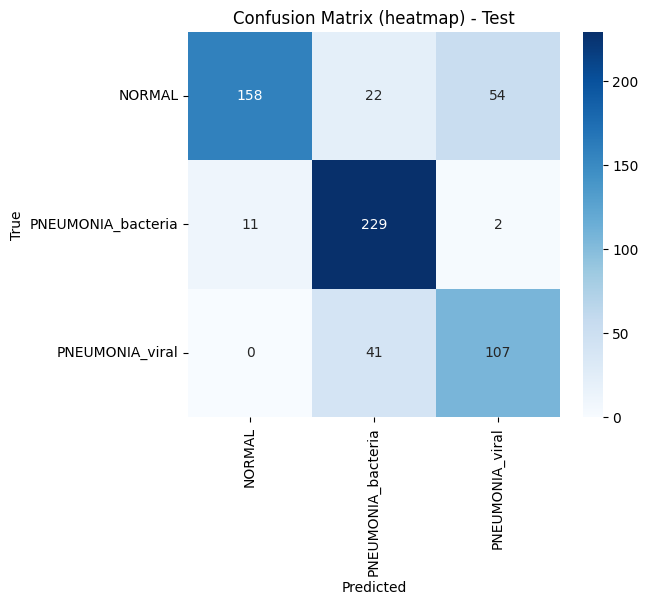

```python
# matrice de confusion et rapport de classification (jeu de test prétraité)
y_true = np.concatenate([y for _, y in test_ds_prep], axis=0)
y_pred_prob = model.predict(test_ds_prep)
y_pred = np.argmax(y_pred_prob, axis=1)
y_true_labels = np.argmax(y_true, axis=1)

print("Classes:", train_class_names)
cm = confusion_matrix(y_true_labels, y_pred)
print("Classification Report:\n", classification_report(y_true_labels, y_pred, target_names=train_class_names))
print("Confusion Matrix:\n", cm)

plt.figure(figsize=(6, 5))
sns.heatmap(cm, annot=True, fmt='d', cmap='Blues', xticklabels=train_class_names, yticklabels=train_class_names)
plt.xlabel('Predicted')
plt.ylabel('True')
plt.title('Confusion Matrix (heatmap) - Test')
plt.show()
```

## 13. Récupération des probabilités prédites

On récupère ici, pour toutes les images de test, les vraies classes et les probabilités prédites par le modèle. On en a besoin pour tracer les courbes ROC et chercher les seuils dans les cellules suivantes.

```python
y_true = []
y_proba = []

for images, labels in test_ds_prep:
    y_true.extend(labels.numpy())
    y_proba.extend(model.predict(images))

y_true = np.array(y_true)
y_proba = np.array(y_proba)
```

[output not shown]

## 14. Courbe ROC et AUC (one-vs-rest)

Comme pour le CNN from scratch, on trace une courbe ROC par classe (one-vs-rest) et on calcule l'AUC de chacune (1 = parfait, 0.5 = au hasard), plus l'AUC moyen. Ça mesure la capacité du modèle à bien séparer chaque classe des autres.

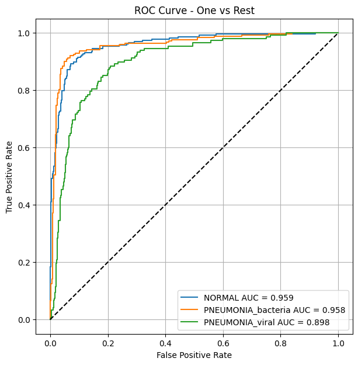

```
AUC moyen macro: 0.9382166812754434
```

```python
# tracer la courbe ROC et calculer l’AUC en one-vs-rest
from sklearn.metrics import roc_curve, auc
import matplotlib.pyplot as plt

y_true_bin = y_true

plt.figure(figsize=(7, 7))
roc_aucs = []
for idx, class_name in enumerate(train_class_names):
    fpr, tpr, _ = roc_curve(y_true_bin[:, idx], y_proba[:, idx])
    roc_auc = auc(fpr, tpr)
    roc_aucs.append(roc_auc)
    plt.plot(fpr, tpr, label=f"{class_name} AUC = {roc_auc:.3f}")

plt.plot([0, 1], [0, 1], 'k--')
plt.xlabel("False Positive Rate")
plt.ylabel("True Positive Rate")
plt.title("ROC Curve - One vs Rest")
plt.legend()
plt.grid()
plt.show()

print("AUC moyen macro:", np.mean(roc_aucs))
```

## 15. Seuils de Youden par classe

On calcule pour chaque classe le **seuil de Youden**, c'est-à-dire le seuil qui offre le meilleur compromis entre vrais positifs et faux positifs sur la courbe ROC.

```python
# Calcul du seuil optimal en utilisant l’indice de Youden pour chaque classe (one-vs-rest)
youden_thresholds = {}
for idx, class_name in enumerate(train_class_names):
    fpr, tpr, thresholds = roc_curve(y_true_bin[:, idx], y_proba[:, idx])
    youden_index = tpr - fpr
    best_idx = np.argmax(youden_index)
    youden_thresholds[class_name] = thresholds[best_idx]
    print(f"Seuil optimal (Youden) pour {class_name}: {thresholds[best_idx]:.3f}")
```

```
Seuil optimal (Youden) pour NORMAL: 0.046
Seuil optimal (Youden) pour PNEUMONIA_bacteria: 0.714
Seuil optimal (Youden) pour PNEUMONIA_viral: 0.245
```

## 16. Décision multiclasses (argmax)

En multi-classes, on ne fixe pas un seul seuil global comme en binaire : la classe prédite est simplement celle qui a la plus grande probabilité (`argmax`). Ces cellules réaffichent le rapport et la matrice de confusion avec cette règle de décision, et rappellent les seuils de Youden par classe à titre indicatif.

```
Décision multiclasses active : argmax(y_proba)
                    precision    recall  f1-score   support

            NORMAL       0.93      0.68      0.78       234
PNEUMONIA_bacteria       0.78      0.95      0.86       242
   PNEUMONIA_viral       0.66      0.72      0.69       148

          accuracy                           0.79       624
         macro avg       0.79      0.78      0.78       624
      weighted avg       0.81      0.79      0.79       624

[[158  22  54]
 [ 11 229   2]
 [  0  41 107]]
```

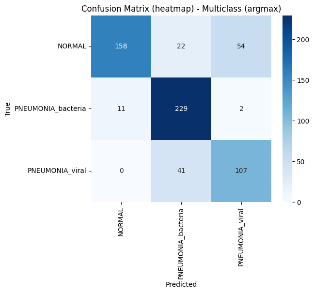

```python
# En multiclasses, on ne retient pas un seuil binaire global.
# La décision finale repose sur l'argmax des probabilités et sur les seuils par classe calculés plus bas.
print("Décision multiclasses active : argmax(y_proba)")
cm = confusion_matrix(y_true_labels, y_pred)
print(classification_report(y_true_labels, y_pred, target_names=train_class_names))
print(cm)

plt.figure(figsize=(6, 5))
sns.heatmap(cm, annot=True, fmt='d', cmap='Blues', xticklabels=train_class_names, yticklabels=train_class_names)
plt.xlabel('Predicted')
plt.ylabel('True')
plt.title('Confusion Matrix (heatmap) - Multiclass (argmax)')
plt.show()
```

```python
# Variante pour forcer un rappel élevé sur la classe Pneumonia_viral si nécessaire
# En multiclasses, on préfère en général ajuster les seuils par classe ou utiliser la matrice de confusion
# plutôt qu'un seuil binaire global.
print("Seuils Youden par classe:", youden_thresholds)
```

```
Seuils Youden par classe: {'NORMAL': np.float64(0.045689694583415985), 'PNEUMONIA_bacteria': np.float64(0.7141476273536682), 'PNEUMONIA_viral': np.float64(0.24547506868839264)}
```

```
                    precision    recall  f1-score   support

            NORMAL       0.93      0.68      0.78       234
PNEUMONIA_bacteria       0.78      0.95      0.86       242
   PNEUMONIA_viral       0.66      0.72      0.69       148

          accuracy                           0.79       624
         macro avg       0.79      0.78      0.78       624
      weighted avg       0.81      0.79      0.79       624

[[158  22  54]
 [ 11 229   2]
 [  0  41 107]]
```

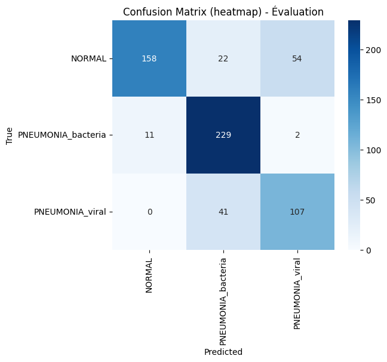

```python
# Évaluer les performances du modèle avec les prédictions multiclasses
from sklearn.metrics import classification_report, confusion_matrix

# Ici on garde la décision argmax globale pour la classification multiclasses.
cm = confusion_matrix(y_true_labels, y_pred)
print(classification_report(y_true_labels, y_pred, target_names=train_class_names))
print(cm)

plt.figure(figsize=(6, 5))
sns.heatmap(cm, annot=True, fmt='d', cmap='Blues', xticklabels=train_class_names, yticklabels=train_class_names)
plt.xlabel('Predicted')
plt.ylabel('True')
plt.title('Confusion Matrix (heatmap) - Évaluation')
plt.show()
```

## 17. Seuils F1 (précision-rappel) par classe

On cherche, pour chaque classe, le seuil qui maximise le **F1-score** à partir de la courbe précision-rappel (même logique que dans l'autre notebook). On réaffiche ensuite le rapport et la matrice de confusion ; la décision finale reste l'`argmax`, les seuils servant surtout d'analyse.

```python
# Seuils PR: en multiclasses, on calcule plutôt les scores PR one-vs-rest par classe.
from sklearn.metrics import precision_recall_curve

pr_thresholds = {}
for idx, class_name in enumerate(train_class_names):
    precision, recall, thresholds = precision_recall_curve(y_true_bin[:, idx], y_proba[:, idx])
    f1_scores = 2 * precision[:-1] * recall[:-1] / (precision[:-1] + recall[:-1] + 1e-8)
    best_idx = np.argmax(f1_scores)
    pr_thresholds[class_name] = thresholds[best_idx]
    print(f"Seuil optimal F1 (PR) pour {class_name} : {thresholds[best_idx]:.3f}")
```

```
Seuil optimal F1 (PR) pour NORMAL : 0.046
Seuil optimal F1 (PR) pour PNEUMONIA_bacteria : 0.744
Seuil optimal F1 (PR) pour PNEUMONIA_viral : 0.454
```

```
Seuils PR par classe: {'NORMAL': np.float32(0.045689695), 'PNEUMONIA_bacteria': np.float32(0.7435901), 'PNEUMONIA_viral': np.float32(0.453616)}
Pour une décision finale multiclasses, on conserve argmax sur les probabilités.
                    precision    recall  f1-score   support

            NORMAL       0.93      0.68      0.78       234
PNEUMONIA_bacteria       0.78      0.95      0.86       242
   PNEUMONIA_viral       0.66      0.72      0.69       148

          accuracy                           0.79       624
         macro avg       0.79      0.78      0.78       624
      weighted avg       0.81      0.79      0.79       624

[[158  22  54]
 [ 11 229   2]
 [  0  41 107]]
```

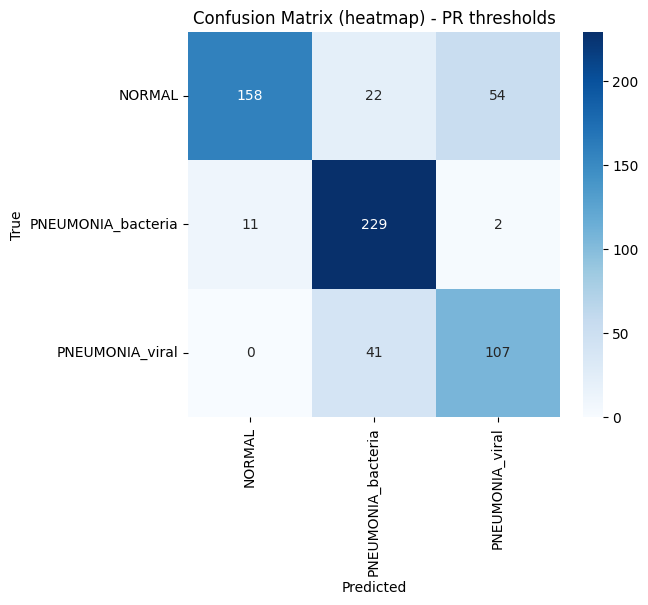

```python
# Évaluer les performances du modèle avec les seuils PR par classe
from sklearn.metrics import classification_report, confusion_matrix

print("Seuils PR par classe:", pr_thresholds)
print("Pour une décision finale multiclasses, on conserve argmax sur les probabilités.")
cm = confusion_matrix(y_true_labels, y_pred)
print(classification_report(y_true_labels, y_pred, target_names=train_class_names))
print(cm)

plt.figure(figsize=(6, 5))
sns.heatmap(cm, annot=True, fmt='d', cmap='Blues', xticklabels=train_class_names, yticklabels=train_class_names)
plt.xlabel('Predicted')
plt.ylabel('True')
plt.title('Confusion Matrix (heatmap) - PR thresholds')
plt.show()
```

## 18. Analyse des faux négatifs / faux positifs

On regarde classe par classe le nombre de vrais positifs (TP), vrais négatifs (TN), faux positifs (FP) et faux négatifs (FN). C'est utile en contexte médical pour repérer, par exemple, sur quelle classe le modèle rate le plus de malades (FN).

```python
# Analyse simple des faux négatifs / faux positifs par classe en multiclasses
rows = []

for idx, class_name in enumerate(train_class_names):
    y_true_class = (y_true_labels == idx).astype(int)
    y_pred_class = (y_pred == idx).astype(int)
    TN, FP, FN, TP = confusion_matrix(y_true_class, y_pred_class).ravel()
    rows.append({"class": class_name, "FN": FN, "FP": FP, "TP": TP, "TN": TN})

df = pd.DataFrame(rows)
print(df)
```

```
                class  FN  FP   TP   TN
0              NORMAL  76  11  158  379
1  PNEUMONIA_bacteria  13  63  229  319
2     PNEUMONIA_viral  41  56  107  420
```

## 19. Matrice de confusion finale

Dernier rappel de la matrice de confusion et du rapport de classification, comme résumé final des performances du modèle sur le test.

```
                    precision    recall  f1-score   support

            NORMAL       0.93      0.68      0.78       234
PNEUMONIA_bacteria       0.78      0.95      0.86       242
   PNEUMONIA_viral       0.66      0.72      0.69       148

          accuracy                           0.79       624
         macro avg       0.79      0.78      0.78       624
      weighted avg       0.81      0.79      0.79       624

[[158  22  54]
 [ 11 229   2]
 [  0  41 107]]
```

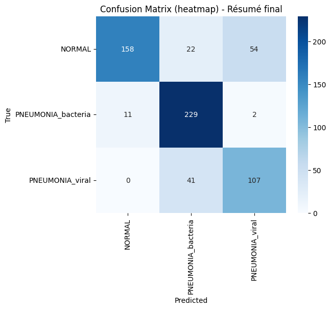

```python
from sklearn.metrics import classification_report, confusion_matrix

cm = confusion_matrix(y_true_labels, y_pred)
print(classification_report(y_true_labels, y_pred, target_names=train_class_names))
print(cm)

plt.figure(figsize=(6, 5))
sns.heatmap(cm, annot=True, fmt='d', cmap='Blues', xticklabels=train_class_names, yticklabels=train_class_names)
plt.xlabel('Predicted')
plt.ylabel('True')
plt.title('Confusion Matrix (heatmap) - Résumé final')
plt.show()
```